# ECE 466 Homework 6

**Spring 22** **Due 4/1/2022**

- You can collaborate on homeworks and turn in a homework for 2 people. Make sure both of you submit.
- Include your codes and answers within the cells that are requested. Do not create additional cells.
- **Upload the `.ipynb` document and a generated `.html` in a zip:**

```python
import numpy as np
import matplotlib.pyplot as plt
from scipy import signal
```

#### 1:

[20] Determine if the Fourier Transform $X(\omega)$ of a signal $x[n]$ is a) even or odd, and b) imarinary or real when $x[n]$ is:

1. Real and even.
2. Imaginary and even.
3. Real and odd.
4. Imaginary and odd.

Show your work.

**Answer for 1.1:**

1. $x[n] = x_R[n]$, where $x_R[n]$ is the real part of $x[n]$. Equivalently, $x_I[n]=0$, where $x_I[n]$ is the imaginary part of $x[n]$.
2. We know that $$X(\omega) = \sum_{n=-\infty}^{\infty} \left(x_R[n]\cos(\omega n)+x_I[n]\sin(\omega n)\right)+j\left( -x_R[n]\sin(\omega n)+x_I[n]\cos(\omega n)\right).$$
3. The sum of an odd function from $-\infty$ to $\infty$ is zero. Thus, $$\sum_{n=-\infty}^{\infty}-x_R[n]\sin(\omega n)=0$$
4. Thus, $X(\omega) = \sum_{n=-\infty}^{\infty} x_R[n]\cos(\omega n).$ Thus, $X(\omega)$ is a sum of a real signal, hence it is always **real**.
5. Also, $X(-\omega) = \sum_{n=-\infty}^{\infty} x_R[n]\cos(-\omega n) = \sum_{n=-\infty}^{\infty} x_R[n]\cos(\omega n) = X(\omega)$, so it is **even**.

**Answer for 1.2:**

Now, we only have $x_I[n].$ so, following a similar analysis as 1.1 (as the $x_I[n]\sin(\omega n)$ is odd), we end up with $$X(\omega) = \sum_{n=-\infty}^{\infty} jx_I[n]\cos(\omega n)$$

1. Since this is the sum of purely imaginary numbers, $X(\omega)$ is **imaginary**.
2. Similar to 1.1, $X(\omega)= X(-\omega),$ hence it is **even**.

**Answer for 1.3:**

Now, since $x_R[n]$ is odd, $x_R[n]\sin(\omega n)$ is going to be even. Hence: $$X(\omega) = \sum_{n=-\infty}^{\infty} -jx_R[n]\sin(\omega n)$$

1. Since this is a sum of purely imaginary numbers, $X(\omega)$ is **imaginary**.
2. Also, $X(-\omega) = \sum_{n=-\infty}^{\infty} -jx_R[n]\sin(-\omega n) = \sum_{n=-\infty}^{\infty} jx_R[n]\sin(\omega n) = -X(\omega)$, so it is **odd**.

**Answer for 1.4:**

Similar to 1.3, we will be left with only $x_I[n]\sin(\omega n)$. $$X(\omega) = \sum_{n=-\infty}^{\infty} x_I[n]\sin(\omega n)$$

1. Since this is a sum of real numbers, $X(\omega)$ is **real**.
2. Following 1.3, $X(\omega)$ is **odd**.

#### 2:

[25 points] Determine and sketch the Fourier transforms $X_1(\omega)$, $X_2(\omega)$, and $X_3(\omega)$ of the following signals:

1. $x_l[n] = \{1, 1, \underline{1}, 1, 1\}.$
2. $x_2[n] = \{1, 0, 1, 0, \underline{1}, 0, 1, 0, 1\}.$
3. $x_3[n] = \{1, 0, 0, 1, 0, 0, \underline{1}, 0, 0, 1, 0, 0, 1\}.$
4. Is there any relation between $X_1(\omega)$, $X_2(\omega)$, and $X_3(\omega)$? What is the physical meaning behind the relationship?
5. Show that if $$x_k[n]=\begin{cases} x\left[\frac{n}{k}\right],\quad &\text{if $n/k$ is integer},\\ 0, &\text{otherwise} \end{cases}$$ then $$X_k(\omega) = X(k\omega).$$

**Answer for 2:**

1. $$X_1(\omega) = \sum_{n=-2}^2 x_1[n]e^{-j\omega n} = e^{j2\omega} + e^{j\omega} + 1 + e^{-j\omega}+e^{-j2\omega} = 1+2\cos(\omega)+2\cos(2\omega) .$$
2. $$X_2(\omega) = \sum_{n=-4}^4 x_2[n]e^{-j\omega n} = e^{j4\omega} + e^{j2\omega} + 1 + e^{-j2\omega}+e^{-j4\omega} = 1+2\cos(2\omega)+2\cos(4\omega) .$$
3. $$X_3(\omega) = \sum_{n=-6}^6 x_3[n]e^{-j\omega n} = e^{j6\omega} + e^{j3\omega} + 1 + e^{-j3\omega}+e^{-j6\omega} = 1+2\cos(3\omega)+2\cos(6\omega) .$$
4. $x_2[n]$ is a upsampled by 2 (resampled by $N=\frac{1}{2}$) version of $x_1[n]$, and $x_3[n]$ is upsampled by 3 version of $x_1[n]$. Resampling in time by a rate lower than 1 causes the spectrum, or frequency domain to shrink.
5. If $$x_k[n] = \begin{cases} x[\frac{n}{k}], \quad & \frac{n}{k} \text{ an integer,}\\ 0, &\text{otherwise} \end{cases}$$ then, $$\begin{align}X_k(\omega) &= \sum_{n=\infty, \frac{n}{k} \text{ an integer}}^{\infty} x_k[n]e^{-j\omega n}\\ &= \sum_{n=-\infty}^{\infty} x[n] e^{-jk\omega n}\\ &= X(k\omega) \end{align}$$

#### 3:

[15 points] A signal $x[n]$ has the following Fourier transform: $$X(\omega)=\frac{1}{1-ae^{-j\omega}}$$ Determine the Fourier transforms of the following signals:

1. $x[2n + 1]$
2. $e^{\pi n/2} x[n + 2]$
3. $x[n]cos(0.3\pi n)$

**Answer for 3.1:**

[figure not shown]

#### 4:

[40 points] Write a python function to compute the DTFT of a finite duration sequence. The format of the function should be as following:

```
def dtft(x, n, w):
    """ DTFT computed at w

    Parameters:
    ---
        x : finite duration sequence over n
        n : sample position vector
        w : frequency location vector

    Returns:
    ---
        X : DTFT values computed at frequencies w
    """

    return X
```

Compute the DTFT for the following sequences by using your code. Choose $\omega$ as an array sampled between $-\pi$ and $\pi$ uniformly (*You can use `np.arange` for this*). Plot the magnitude and angle of $X(\omega)$:

1. $x[n] = \{\underline{4},3,2,1,2,3,4\}$. Comment on the angle plot.
2. $$x[n] = \begin{cases} 1, \quad &-N\leq n\leq N, \\ 0, &\text{otherwise}. \end{cases}$$ Determine the DTFT for $N = 5, 25, 100$. Scale the DTFT so that $X(0)=1.$ Comment on the behavior of the magnitude plot as a function of N.

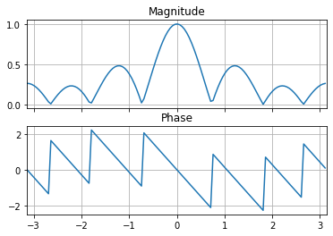

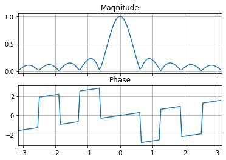

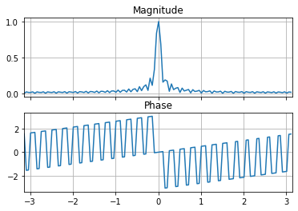

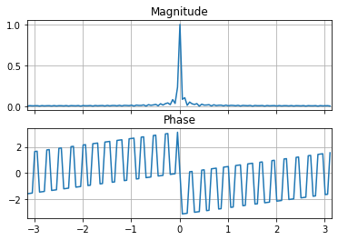

```python
# Code for question 4

def dtft(x, n, w):
    """ DTFT computed at w

    Parameters:
    ---
        x : finite duration sequence over n
        n : sample position vector
        w : frequency location vector

    Returns:
    ---
        X : DTFT values computed at frequencies w
    """
    N = len(n)
    X = np.zeros_like(w)
    for i in range(N):
        X = X + x[i]*np.exp(-1j*n[i]*w)

    mag_X = np.abs(X)
    angle_X = np.angle(X)
    fig, (ax1, ax2) = plt.subplots(2,1, sharex=True)
    ax1.plot(w, mag_X/mag_X.max())
    ax1.set_title('Magnitude')
    ax1.grid()
    ax2.plot(w, angle_X)
    ax2.set_title('Phase')
    ax2.set_xlim(-np.pi, np.pi)
    ax2.grid()

    return X

x_1 = [4,3,2,1,2,3,4]
n = np.arange(7)
w = np.arange(-np.pi, np.pi, 0.05)
X_1 = dtft(x_1, n, w)

K = 5
x_2 = np.ones(2*K)
n = np.arange(-K, K, 1)
X_2 = dtft(x_2, n, w)

K = 25
x_3 = np.ones(2*K)
n = np.arange(-K, K, 1)
X_3 = dtft(x_3, n, w)

K = 100
x_4 = np.ones(2*K)
n = np.arange(-K, K, 1)
X_4 = dtft(x_4, n, w)
```

**Answer for 4.1:**

The phase is linear as the signal is a time shifted version of an even signal.

**Answer for 4.2:**

As $N$ increases, the main frequency band gets narrower. This reduces the bandwidth.